# Hakuba_forecast_v3_snow

## **白馬村天氣預測(開發版本 v3 - 預測下雪)**

```python
import warnings
import os

# 1. 隱藏 Python 標準警告
warnings.filterwarnings('ignore', category=UserWarning)

# 2. 隱藏 TensorFlow/Keras 的日誌訊息
os.environ['TF_CPP_MIN_LOG_LEVEL'] = '2'
```

**測試**

```python
import pandas as pd
import numpy as np
from tensorflow.keras.layers import Input
from sklearn.preprocessing import MinMaxScaler

############################
# 讀取資料檔案
############################
# 讀取 CSV 檔
df = pd.read_csv("JMA_Hakuba_0396_2016-2026_Final.csv")
#Precip_mm_total	Temp_C_Avg	Temp_C_Max	Temp_C_Min	Wind_ms_Avg	Wind_ms_Max	Sunshine_hr	Snowfall_cm	SnowDepth_cm_Max

# 看前 5 筆資料
#df.head()

# 認識資料欄位
df.info()

############################
# 規範會下雪的週期性特徵季節
# 週期性特徵編碼（Cyclic Encoding）
############################

# 1. 將字串轉換為 datetime 格式
df['Date'] = pd.to_datetime(df['Date'])

# 2. 提取「月份」與「一年的第幾天」
df['month'] = df['Date'].dt.month
df['day_of_year'] = df['Date'].dt.dayofyear

# 3. 進行週期性轉換 (Sin/Cos Encoding)
#    建立月份的週期特徵 (以 12 個月為一週期)
df['month_sin'] = np.sin(2 * np.pi * df['month'] / 12)
df['month_cos'] = np.cos(2 * np.pi * df['month'] / 12)

# 4. 建立日期的週期特徵
df['day_sin'] = np.sin(2 * np.pi * df['day_of_year'] / 365.25)
df['day_cos'] = np.cos(2 * np.pi * df['day_of_year'] / 365.25)

print("轉換後的特徵預覽：")
print(df[['Date', 'month_sin', 'month_cos', 'day_sin', 'day_cos']].head())
```

```
<class 'pandas.core.frame.DataFrame'>
RangeIndex: 3684 entries, 0 to 3683
Data columns (total 10 columns):
 #   Column    Non-Null Count  Dtype
---  ------    --------------  -----
 0   Date      3684 non-null   object
 1   prcp      3684 non-null   float64
 2   tavg      3684 non-null   float64
 3   tmax      3684 non-null   float64
 4   tmin      3684 non-null   float64
 5   wdspavg   3677 non-null   float64
 6   wdspmax   3677 non-null   float64
 7   sunhour   3683 non-null   float64
 8   snowf     3657 non-null   float64
 9   snowdmax  3657 non-null   float64
dtypes: float64(9), object(1)
memory usage: 287.9+ KB
轉換後的特徵預覽：
        Date  month_sin  month_cos   day_sin   day_cos
0 2016-01-01        0.5   0.866025  0.017202  0.999852
1 2016-01-02        0.5   0.866025  0.034398  0.999408
2 2016-01-03        0.5   0.866025  0.051584  0.998669
3 2016-01-04        0.5   0.866025  0.068755  0.997634
4 2016-01-05        0.5   0.866025  0.085906  0.996303
```

# 第一階段：資料獲取與清洗 (Data Acquisition)

特徵選擇：  
(1)平均氣溫 (tavg)：影響雪是否會融化。  
(2)降水量 (prcp)：雪的來源（水氣）。  
(3)週期性特徵 (month_sin, month_cos)：讓 AI 知道現在是冬天。

```python
import pandas as pd
import numpy as np
from sklearn.preprocessing import MinMaxScaler
from tensorflow.keras.layers import Input

# 1. 重新讀取原始資料 (確保欄位齊全)
df = pd.read_csv('JMA_Hakuba_0396_2016-2026_Final.csv')

# 2. 日期轉換與週期特徵 (Sin/Cos)
df['Date'] = pd.to_datetime(df['Date'])
df['month'] = df['Date'].dt.month
df['month_sin'] = np.sin(2 * np.pi * df['month'] / 12)
df['month_cos'] = np.cos(2 * np.pi * df['month'] / 12)

# 3. 挑選要訓練的 5 個特徵 (注意：這裡直接使用原始欄位名稱)
# 我們包含：平均氣溫、降水量、降雪量、月份Sin、月份Cos
features_cols = ['tavg', 'prcp', 'snowf', 'month_sin', 'month_cos']

# 檢查欄位是否都存在，避免再次報錯
for col in features_cols:
    if col not in df.columns:
        print(f"錯誤：找不到欄位 {col}")

# 4. 處理缺失值並轉換成數值矩陣
# ffill 是用前一天的值填充，避免資料中斷
#dataset = df[features_cols].fillna(method='ffill').fillna(0).values #已棄用寫法
dataset = df[features_cols].ffill().fillna(0).values

# 5. 數值縮放 (Scaling)
scaler = MinMaxScaler(feature_range=(0, 1))
scaled_data = scaler.fit_transform(dataset)

# 6. 打包成 3D 陣列 (LSTM 專用格式)
def create_sequences(data, window_size):
    X = []
    y = []
    for i in range(len(data) - window_size):
        X.append(data[i : i + window_size])
        # 我們預測隔天的 tavg (索引為 0)
        y.append(data[i + window_size, 0])
    return np.array(X), np.array(y)

window_size = 10
X, y = create_sequences(scaled_data, window_size)


##############################
# 資料切割
# 70%訓練 / 15%測試 / 15%驗證
##############################
# 假設 X 和 y 已經準備好 (3D 陣列)
total_samples = len(X)

# 計算各區段的結束索引
train_end = int(total_samples * 0.70)
val_end = int(total_samples * 0.85) # 70% + 15% = 85%

# 進行切割
X_train, y_train = X[:train_end], y[:train_end]
X_val, y_val = X[train_end:val_end], y[train_end:val_end]
X_test, y_test = X[val_end:], y[val_end:]

print(f"訓練集 (70%): {len(X_train)}")
print(f"驗證集 (15%): {len(X_val)}")
print(f"測試集 (15%): {len(X_test)}")


print(f"成功！目前資料形狀：")
print(f"X (輸入): {X.shape}  -> {X.shape[0]} 個樣本, 每個包含 {X.shape[1]} 天, 每層有 {X.shape[2]} 個特徵")
print(f"y (目標): {y.shape}")
```

```
訓練集 (70%): 2571
驗證集 (15%): 551
測試集 (15%): 552
成功！目前資料形狀：
X (輸入): (3674, 10, 5)  -> 3674 個樣本, 每個包含 10 天, 每層有 5 個特徵
y (目標): (3674,)
```

# **定義模型（LSTM）**

```python
##############################
# 定義模型架構
##############################
from tensorflow.keras.models import Sequential
from tensorflow.keras.layers import LSTM, Dense, Dropout
from tensorflow.keras.layers import Input

# 1. 初始化模型 (Sequential 代表積木是由下往上堆疊的)
model = Sequential()

# 2. 加入第一層：LSTM 層
# units=50: 代表這層有 50 個神經元，負責學習特徵
# input_shape=(7, 5): 7 代表看過去 7 天，5 代表每台有 5 個特徵 (tavg, prcp, snowf, month_sin, month_cos)
# 若要加入兩層LSTM、則return_sequences需設為True
model.add(LSTM(units=50, return_sequences=False, input_shape=(X.shape[1], X.shape[2])))
#model = Sequential([
#    Input(shape=(7, 9)),  # 第一層專門定義輸入形狀 (WINDOW_SIZE, FEATURES)
#    LSTM(64, return_sequences=True),
#    Dropout(0.2),
#    LSTM(32),
#    Dense(5)
#])

# 3. 加入 Dropout 層 (防止過擬合/死背)
# 0.2 代表在訓練時隨機「關掉」20% 的神經元，強迫模型學習更穩健的規律
model.add(Dropout(0.2))

# 4. 加入輸出層 (Dense)
# 因為我們只需要預測一個數字（明天的溫度），所以單位是 1
model.add(Dense(units=1))

# 5. 編譯模型
# optimizer='adam': 這是一個自動調整學習率的優化器（就像是自動導航）
# loss='mean_squared_error': 損失函數，用來計算「預測值」與「真實值」的差距平方
model.compile(optimizer='adam', loss='mean_squared_error')

# 顯示模型摘要
model.summary()
```

```
Model: "sequential"
```

```
┏━━━━━━━━━━━━━━━━━━━━━━━━━━━━━━━━━┳━━━━━━━━━━━━━━━━━━━━━━━━┳━━━━━━━━━━━━━━━┓
┃ Layer (type)                    ┃ Output Shape           ┃       Param # ┃
┡━━━━━━━━━━━━━━━━━━━━━━━━━━━━━━━━━╇━━━━━━━━━━━━━━━━━━━━━━━━╇━━━━━━━━━━━━━━━┩
│ lstm (LSTM)                     │ (None, 50)             │        11,200 │
├─────────────────────────────────┼────────────────────────┼───────────────┤
│ dropout (Dropout)               │ (None, 50)             │             0 │
├─────────────────────────────────┼────────────────────────┼───────────────┤
│ dense (Dense)                   │ (None, 1)              │            51 │
└─────────────────────────────────┴────────────────────────┴───────────────┘
```

```
 Total params: 11,251 (43.95 KB)
```

```
 Trainable params: 11,251 (43.95 KB)
```

```
 Non-trainable params: 0 (0.00 B)
```

```python
##############################
# 開始訓練 (Training)
##############################
# 開始訓練
# validation_split=0.2: 拿 20% 的資料來當「模擬考」，不參與學習，只用來觀察準確度
# epochs=50: 所有的資料要重複看 50 遍
# batch_size=32: 每次餵 32 筆資料後就更新一次權重（就像是讀 32 頁書後做一次筆記）
'''
history = model.fit(
    X, y,
    epochs=50,
    batch_size=32,
    validation_split=0.2,
    verbose=1
)
'''
# 訓練時的寫法也要改：
# 不要用 validation_split，改用指定的 validation_data
history = model.fit(
    X_train, y_train,
    epochs=50,
    batch_size=32,
    validation_data=(X_val, y_val), # 使用我們切好的 15% 驗證集
    verbose=1
)
```

```
81/81 ━━━━━━━━━━━━━━━━━━━━ 3s 10ms/step - loss: 0.1278 - val_loss: 0.0052
81/81 ━━━━━━━━━━━━━━━━━━━━ 1s 7ms/step - loss: 0.0109 - val_loss: 0.0051
81/81 ━━━━━━━━━━━━━━━━━━━━ 1s 7ms/step - loss: 0.0093 - val_loss: 0.0069
81/81 ━━━━━━━━━━━━━━━━━━━━ 1s 7ms/step - loss: 0.0086 - val_loss: 0.0048
81/81 ━━━━━━━━━━━━━━━━━━━━ 1s 7ms/step - loss: 0.0078 - val_loss: 0.0049
81/81 ━━━━━━━━━━━━━━━━━━━━ 1s 7ms/step - loss: 0.0075 - val_loss: 0.0046
81/81 ━━━━━━━━━━━━━━━━━━━━ 1s 7ms/step - loss: 0.0068 - val_loss: 0.0045
81/81 ━━━━━━━━━━━━━━━━━━━━ 1s 7ms/step - loss: 0.0070 - val_loss: 0.0044
81/81 ━━━━━━━━━━━━━━━━━━━━ 1s 7ms/step - loss: 0.0065 - val_loss: 0.0045
81/81 ━━━━━━━━━━━━━━━━━━━━ 1s 10ms/step - loss: 0.0063 - val_loss: 0.0043
81/81 ━━━━━━━━━━━━━━━━━━━━ 1s 11ms/step - loss: 0.0061 - val_loss: 0.0048
81/81 ━━━━━━━━━━━━━━━━━━━━ 1s 12ms/step - loss: 0.0060 - val_loss: 0.0048
81/81 ━━━━━━━━━━━━━━━━━━━━ 1s 8ms/step - loss: 0.0058 - val_loss: 0.0043
81/81 ━━━━━━━━━━━━━━━━━━━━ 1s 7ms/step - loss: 0.0057 - val_loss: 0.0046
81/81 ━━━━━━━━━━━━━━━━━━━━ 1s 7ms/step - loss: 0.0056 - val_loss: 0.0042
81/81 ━━━━━━━━━━━━━━━━━━━━ 1s 7ms/step - loss: 0.0055 - val_loss: 0.0041
81/81 ━━━━━━━━━━━━━━━━━━━━ 1s 7ms/step - loss: 0.0055 - val_loss: 0.0042
81/81 ━━━━━━━━━━━━━━━━━━━━ 1s 7ms/step - loss: 0.0055 - val_loss: 0.0040
81/81 ━━━━━━━━━━━━━━━━━━━━ 1s 7ms/step - loss: 0.0052 - val_loss: 0.0040
81/81 ━━━━━━━━━━━━━━━━━━━━ 1s 7ms/step - loss: 0.0054 - val_loss: 0.0041
81/81 ━━━━━━━━━━━━━━━━━━━━ 1s 7ms/step - loss: 0.0054 - val_loss: 0.0041
81/81 ━━━━━━━━━━━━━━━━━━━━ 1s 7ms/step - loss: 0.0053 - val_loss: 0.0043
81/81 ━━━━━━━━━━━━━━━━━━━━ 1s 7ms/step - loss: 0.0051 - val_loss: 0.0041
81/81 ━━━━━━━━━━━━━━━━━━━━ 1s 7ms/step - loss: 0.0051 - val_loss: 0.0039
81/81 ━━━━━━━━━━━━━━━━━━━━ 1s 7ms/step - loss: 0.0049 - val_loss: 0.0041
81/81 ━━━━━━━━━━━━━━━━━━━━ 1s 7ms/step - loss: 0.0053 - val_loss: 0.0038
81/81 ━━━━━━━━━━━━━━━━━━━━ 1s 7ms/step - loss: 0.0049 - val_loss: 0.0044
81/81 ━━━━━━━━━━━━━━━━━━━━ 1s 7ms/step - loss: 0.0050 - val_loss: 0.0038
81/81 ━━━━━━━━━━━━━━━━━━━━ 1s 8ms/step - loss: 0.0055 - val_loss: 0.0037
81/81 ━━━━━━━━━━━━━━━━━━━━ 2s 11ms/step - loss: 0.0048 - val_loss: 0.0039
81/81 ━━━━━━━━━━━━━━━━━━━━ 1s 10ms/step - loss: 0.0048 - val_loss: 0.0037
81/81 ━━━━━━━━━━━━━━━━━━━━ 1s 7ms/step - loss: 0.0047 - val_loss: 0.0041
81/81 ━━━━━━━━━━━━━━━━━━━━ 1s 7ms/step - loss: 0.0047 - val_loss: 0.0037
81/81 ━━━━━━━━━━━━━━━━━━━━ 1s 7ms/step - loss: 0.0047 - val_loss: 0.0039
81/81 ━━━━━━━━━━━━━━━━━━━━ 1s 7ms/step - loss: 0.0046 - val_loss: 0.0036
81/81 ━━━━━━━━━━━━━━━━━━━━ 1s 16ms/step - loss: 0.0046 - val_loss: 0.0039
81/81 ━━━━━━━━━━━━━━━━━━━━ 1s 15ms/step - loss: 0.0044 - val_loss: 0.0038
81/81 ━━━━━━━━━━━━━━━━━━━━ 1s 7ms/step - loss: 0.0044 - val_loss: 0.0034
81/81 ━━━━━━━━━━━━━━━━━━━━ 1s 7ms/step - loss: 0.0042 - val_loss: 0.0034
81/81 ━━━━━━━━━━━━━━━━━━━━ 1s 7ms/step - loss: 0.0041 - val_loss: 0.0034
81/81 ━━━━━━━━━━━━━━━━━━━━ 1s 7ms/step - loss: 0.0042 - val_loss: 0.0035
81/81 ━━━━━━━━━━━━━━━━━━━━ 1s 8ms/step - loss: 0.0042 - val_loss: 0.0035
81/81 ━━━━━━━━━━━━━━━━━━━━ 1s 7ms/step - loss: 0.0039 - val_loss: 0.0033
81/81 ━━━━━━━━━━━━━━━━━━━━ 1s 7ms/step - loss: 0.0040 - val_loss: 0.0033
81/81 ━━━━━━━━━━━━━━━━━━━━ 1s 11ms/step - loss: 0.0039 - val_loss: 0.0032
81/81 ━━━━━━━━━━━━━━━━━━━━ 1s 11ms/step - loss: 0.0039 - val_loss: 0.0032
81/81 ━━━━━━━━━━━━━━━━━━━━ 1s 11ms/step - loss: 0.0039 - val_loss: 0.0033
81/81 ━━━━━━━━━━━━━━━━━━━━ 1s 7ms/step - loss: 0.0039 - val_loss: 0.0031
81/81 ━━━━━━━━━━━━━━━━━━━━ 1s 7ms/step - loss: 0.0037 - val_loss: 0.0032
81/81 ━━━━━━━━━━━━━━━━━━━━ 1s 7ms/step - loss: 0.0038 - val_loss: 0.0030
```

# 計算 MAE (平均絕對誤差)

```python
###########################################
# 由於數值還在 0~1 之間，必須先把模型預測出來的結果（Scaled Value），
# 透過 scaler 還原回原始的攝氏溫度，算出來的 MAE 才有物理意義（例如：誤差 1.5 度）。
###########################################

from sklearn.metrics import mean_absolute_error

# A. 用測試集 (模型沒看過的資料) 進行預測
y_pred_scaled = model.predict(X_test)

# B. 將預測值還原 (Inverse Transform)
# 技巧：因為 scaler 當初是吃 5 個特徵，我們需要建立一個臨時的 5 欄矩陣來還原
def inverse_transform_y(y_scaled, scaler, num_features=5):
    dummy = np.zeros((len(y_scaled), num_features))
    dummy[:, 0] = y_scaled.flatten() # 假設溫度在第 0 欄
    return scaler.inverse_transform(dummy)[:, 0]

y_pred_final = inverse_transform_y(y_pred_scaled, scaler)
y_test_final = inverse_transform_y(y_test, scaler)

# C. 計算 MAE
mae = mean_absolute_error(y_test_final, y_pred_final)

print(f"模型在測試集上的 MAE 值為: {mae:.4f}")
print(f"這代表平均預測誤差大約是 {mae:.2f} °C")
```

```
18/18 ━━━━━━━━━━━━━━━━━━━━ 0s 13ms/step
模型在測試集上的 MAE 值為: 1.3723
這代表平均預測誤差大約是 1.37 °C
```

在深度學習中，要看**Loss (損失函數)**的變化趨勢。  
完成的徵兆：當 loss (訓練集) 和 val_loss (驗證集) 兩條線都已經降到低點，且開始水平橫移（不再大幅下降），這時才算訓練完成。  
警訊：如果 loss 持續下降，但 val_loss 卻開始往上升，這代表「過擬合 (Overfitting)」，模型死背了答案，這時應該提早停止訓練。

# **將訓練結果視覺化**

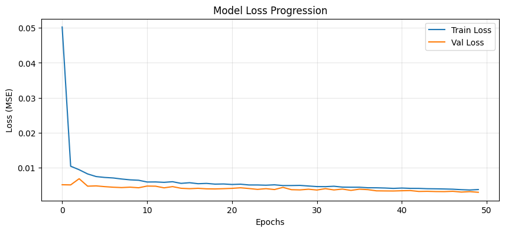

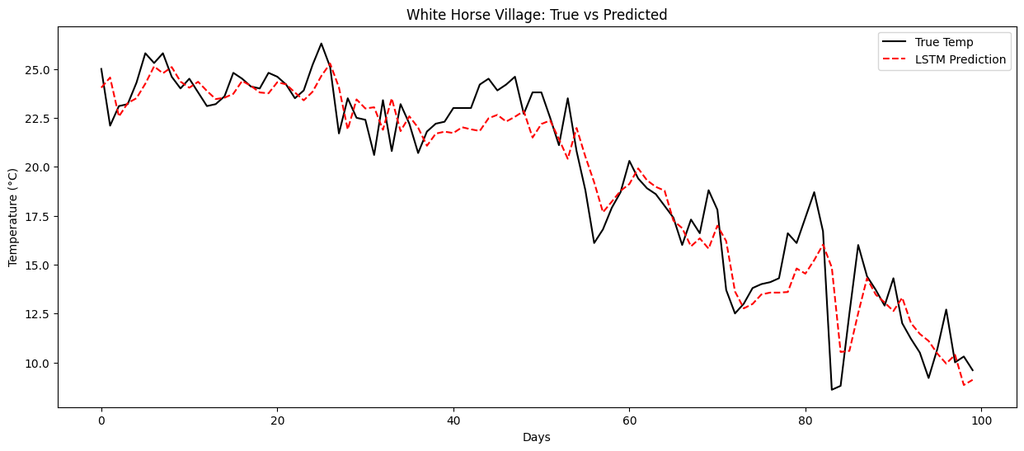

```python
###############################################
# A. 繪製學習曲線 (Loss Curve)
###############################################
import matplotlib.pyplot as plt

# A. 學習曲線
plt.figure(figsize=(10, 4))
plt.plot(history.history['loss'], label='Train Loss')
plt.plot(history.history['val_loss'], label='Val Loss')
plt.title('Model Loss Progression')
plt.xlabel('Epochs')
plt.ylabel('Loss (MSE)')
plt.legend()
plt.grid(True, alpha=0.3)
plt.show()

###############################################
# B. 繪製真實值 vs. 預測值 (測試集)
###############################################
# 這裡使用我們之前算出的 y_test_final 和 y_pred_final
plt.figure(figsize=(15, 6))
plt.plot(y_test_final[:100], label='True Temp', color='black')
plt.plot(y_pred_final[:100], label='LSTM Prediction', color='red', ls='--')
plt.title('White Horse Village: True vs Predicted')
plt.xlabel('Days')
plt.ylabel('Temperature (°C)')
plt.legend()
plt.show()
```

# **多目標預測（Multi-Output）& 遞迴式未來預測（Recursive Forecasting）**

# 升級模型為「多目標輸出」

```python
# 1. 重新打包資料，y 現在包含兩個值：[tavg, snowf]
def create_multi_output_sequences(data, window_size):
    X, y = [], []
    for i in range(len(data) - window_size):
        X.append(data[i : i + window_size])
        # 索引 0 是 tavg, 索引 2 是 snowf (對應之前的 features_cols)
        y.append(data[i + window_size, [0, 2]])
    return np.array(X), np.array(y)

X, y = create_multi_output_sequences(scaled_data, window_size)

# 2. 重新切割資料 (70/15/15)
train_end = int(len(X) * 0.7)
val_end = int(len(X) * 0.85)
X_train, y_train = X[:train_end], y[:train_end]
X_val, y_val = X[train_end:val_end], y[train_end:val_end]

# 3. 建立新模型 (輸出層改為 2)
model = Sequential([
    LSTM(50, input_shape=(X.shape[1], X.shape[2])),
    Dropout(0.2),
    Dense(2) # 同時輸出：溫度、降雪量
])
model.compile(optimizer='adam', loss='mse')
model.fit(X_train, y_train, epochs=50, batch_size=32, validation_data=(X_val, y_val), verbose=0)

print("模型升級完成：現在可以同時預測溫度與降雪量了！")
```

```
模型升級完成：現在可以同時預測溫度與降雪量了！
```

# 預測未來 3 天的邏輯

```python
# 取得資料集最後一天的日期，用來推算未來日期
last_date = df['Date'].iloc[-1]
future_dates = [last_date + pd.Timedelta(days=i) for i in range(1, 4)]

# 取得最後 7 天的資料作為啟動點 (Shape: 1, 7, 5)
current_batch = scaled_data[-window_size:].reshape(1, window_size, 5)

future_preds = []

for i in range(3):
    # 1. 預測隔天 [Temp, Snow]
    pred_scaled = model.predict(current_batch)[0]

    # 2. 儲存結果
    future_preds.append(pred_scaled)

    # 3. 準備下一輪的輸入：
    # 我們需要更新 Sin/Cos 週期特徵，這裡簡單處理：假設未來 3 天月份不變
    # 實際開發會重新計算該日期的 Sin/Cos
    next_month = future_dates[i].month
    next_sin = np.sin(2 * np.pi * next_month / 12)
    next_cos = np.cos(2 * np.pi * next_month / 12)

    # 構建新的數據點 [Temp_pred, Prcp(假設為0), Snow_pred, Month_sin, Month_cos]
    new_entry = np.array([pred_scaled[0], 0, pred_scaled[1], next_sin, next_cos]).reshape(1, 1, 5)

    # 剔除掉最舊的一天，加入預測的這一天 (Slide Window)
    current_batch = np.append(current_batch[:, 1:, :], new_entry, axis=1)

# 4. 還原數值 (Inverse Transform)
# 建立一個臨時矩陣來還原
dummy = np.zeros((3, 5))
for i in range(3):
    dummy[i, 0] = future_preds[i][0] # 溫度
    dummy[i, 2] = future_preds[i][1] # 降雪

final_res = scaler.inverse_transform(dummy)

# 5. 輸出結果
print("\n--- 未來三日預測結果 ---")
for i, date in enumerate(future_dates):
    temp = final_res[i, 0]
    snow = final_res[i, 2]
    # 判斷是否降雪 (門檻值可設為 0.1cm)
    will_snow = "會下雪 ❄️" if snow > 0.5 else "不會下雪 ☁️"
    print(f"{date.date()}: 預測氣溫 {temp:.1f}°C, 預測降雪量 {snow:.1f}cm ({will_snow})")
```

```
1/1 ━━━━━━━━━━━━━━━━━━━━ 0s 257ms/step
1/1 ━━━━━━━━━━━━━━━━━━━━ 0s 50ms/step
1/1 ━━━━━━━━━━━━━━━━━━━━ 0s 46ms/step

--- 未來三日預測結果 ---
2026-02-01: 預測氣溫 -2.6°C, 預測降雪量 3.3cm (會下雪 ❄️)
2026-02-02: 預測氣溫 -1.1°C, 預測降雪量 3.9cm (會下雪 ❄️)
2026-02-03: 預測氣溫 -0.1°C, 預測降雪量 3.9cm (會下雪 ❄️)
```

# **擴充特徵與目標 (Features & Targets)**

```python
################################################
# 變更資料處理方式
################################################
import pandas as pd
import numpy as np
from sklearn.preprocessing import MinMaxScaler

# 1. 重新整理特徵欄位 (共 7 個特徵)
# 索引順序：0:tavg, 1:tmax, 2:tmin, 3:prcp, 4:snowf, 5:month_sin, 6:month_cos
features_cols = ['tavg', 'tmax', 'tmin', 'prcp', 'snowf', 'month_sin', 'month_cos']
#dataset = df[features_cols].fillna(method='ffill').fillna(0).values #已廢棄寫法
dataset = df[features_cols].ffill().fillna(0).values

# 2. 數值縮放
scaler = MinMaxScaler(feature_range=(0, 1))
scaled_data = scaler.fit_transform(dataset)

# 3. 定義多目標序列 (同時預測 4 個目標)
def create_all_outputs_sequences(data, window_size):
    X, y = [], []
    for i in range(len(data) - window_size):
        X.append(data[i : i + window_size])
        # 我們要預測隔天的：tavg(0), tmax(1), tmin(2), snowf(4)
        y.append(data[i + window_size, [0, 1, 2, 4]])
    return np.array(X), np.array(y)

window_size = 7
X, y = create_all_outputs_sequences(scaled_data, window_size)

print(f"X 的形狀: {X.shape} (7天, 7特徵)")
print(f"y 的形狀: {y.shape} (預測4個值)")

################################################
# 更新模型架構
################################################
from tensorflow.keras.models import Sequential
from tensorflow.keras.layers import LSTM, Dense, Dropout

model = Sequential([
    LSTM(64, input_shape=(X.shape[1], X.shape[2])), # 增加到 64 讓模型更有力
    Dropout(0.2),
    Dense(4) # 輸出：平均溫、最高溫、最低溫、降雪量
])
model.compile(optimizer='adam', loss='mse')

# 進行訓練 (這裡假設你已經切分好 X_train, y_train)
# 為了教學快速，直接用全量 X, y 演示訓練
model.fit(X, y, epochs=50, batch_size=32, verbose=0)
print("模型訓練完成：現在具備預測高低溫的能力！")


################################################
# 預測未來三天的「高低溫範圍」
################################################
# 取得最後 7 天的資料作為種子
current_batch = scaled_data[-window_size:].reshape(1, window_size, 7)
future_results = []

for i in range(3):
    # 預測 [tavg, tmax, tmin, snowf]
    pred = model.predict(current_batch, verbose=0)[0]
    future_results.append(pred)

    # 構建下一天的輸入 (需更新週期特徵)
    next_date = df['Date'].iloc[-1] + pd.Timedelta(days=i+1)
    m_sin = np.sin(2 * np.pi * next_date.month / 12)
    m_cos = np.cos(2 * np.pi * next_date.month / 12)

    # [tavg_p, tmax_p, tmin_p, prcp=0, snowf_p, m_sin, m_cos]
    new_entry = np.array([pred[0], pred[1], pred[2], 0, pred[3], m_sin, m_cos]).reshape(1, 1, 7)
    current_batch = np.append(current_batch[:, 1:, :], new_entry, axis=1)

# 還原數值
dummy = np.zeros((3, 7))
for i in range(3):
    dummy[i, 0] = future_results[i][0] # tavg
    dummy[i, 1] = future_results[i][1] # tmax
    dummy[i, 2] = future_results[i][2] # tmin
    dummy[i, 4] = future_results[i][3] # snowf

final_res = scaler.inverse_transform(dummy)

# 輸出結果
print("\n--- 白馬村未來三日詳細氣溫預報 ---")
for i in range(3):
    date = df['Date'].iloc[-1] + pd.Timedelta(days=i+1)
    tavg, tmax, tmin, snow = final_res[i, 0], final_res[i, 1], final_res[i, 2], final_res[i, 4]

    print(f"{date.date()}:")
    print(f"  🌡️ 氣溫範圍: {tmin:.1f}°C ~ {tmax:.1f}°C (平均 {tavg:.1f}°C)")
    print(f"  ❄️ 預測降雪: {snow:.1f} cm {'(大雪預警!)' if snow > 5 else ''}")
```

```
X 的形狀: (3677, 7, 7) (7天, 7特徵)
y 的形狀: (3677, 4) (預測4個值)
模型訓練完成：現在具備預測高低溫的能力！

--- 白馬村未來三日詳細氣溫預報 ---
2026-02-01:
  🌡️ 氣溫範圍: -7.2°C ~ 1.2°C (平均 -3.2°C)
  ❄️ 預測降雪: 3.4 cm
2026-02-02:
  🌡️ 氣溫範圍: -5.4°C ~ 2.4°C (平均 -1.7°C)
  ❄️ 預測降雪: 4.3 cm
2026-02-03:
  🌡️ 氣溫範圍: -4.7°C ~ 3.6°C (平均 -0.8°C)
  ❄️ 預測降雪: 4.4 cm
```

# **指定預測某一天的溫度與降雪**

```python
from datetime import datetime

def predict_at_date(target_date_str, model, scaler, df, window_size=7):
    target_date = pd.to_datetime(target_date_str)
    last_date = df['Date'].max()


# 1. 如果日期在歷史資料內，直接回傳
    if target_date <= last_date:
        row = df[df['Date'] == target_date]
        if not row.empty:
            return row['tavg'].values[0], row['tmax'].values[0], row['tmin'].values[0], row['snowf'].values[0]

    # 2. 如果是未來日期，準備預測
    # 注意：這裡必須包含所有 9 個特徵！
    features_cols = ['tavg', 'tmax', 'tmin', 'prcp', 'snowf', 'snowdmax', 'sunhour', 'month_sin', 'month_cos']

    # 確保資料齊全並轉為 numpy
    last_data_raw = df[features_cols].tail(window_size).fillna(0).values

    # 現在 scaler 收到 9 個特徵，就不會報錯了
    last_data_scaled = scaler.transform(last_data_raw)

    current_batch = last_data_scaled.reshape(1, window_size, 9)
    final_pred = None

    days_to_predict = (target_date - last_date).days
    for i in range(days_to_predict):
        # 模型會輸出 5 個預測值：[tavg, tmax, tmin, snowf, snowdmax]
        pred = model.predict(current_batch, verbose=0)[0]

        current_date = last_date + pd.Timedelta(days=i+1)
        m_sin = np.sin(2 * np.pi * current_date.month / 12)
        m_cos = np.cos(2 * np.pi * current_date.month / 12)

        # 構造新的 9 特徵輸入點
        # 順序: [tavg, tmax, tmin, prcp(0), snowf, snowdmax, sunhour(0.5), m_sin, m_cos]
        new_entry = np.array([pred[0], pred[1], pred[2], 0, pred[3], pred[4], 0.5, m_sin, m_cos]).reshape(1, 1, 9)
        current_batch = np.append(current_batch[:, 1:, :], new_entry, axis=1)
        final_pred = pred

    # 3. 還原數值 (建立 9 欄的 dummy 矩陣)
    dummy = np.zeros((1, 9))
    dummy[0, 0:3] = final_pred[0:3] # tavg, tmax, tmin
    dummy[0, 4:6] = final_pred[3:5] # snowf, snowdmax
    res = scaler.inverse_transform(dummy)[0]

    return res[0], res[1], res[2], res[4]



# --- 點名測測看 ---
my_date = "2025-02-01"
tavg, tmax, tmin, snow = predict_at_date(my_date, model, scaler, df)
print(f"【{my_date} 白馬村預測】")
print(f" 🌡️ 均溫: {tavg:.1f}°C (範圍: {tmin:.1f}~{tmax:.1f}°C)")
print(f" ❄️ 降雪: {snow:.1f} cm {'(會有雪！)' if snow > 0.5 else '(無雪)'}")
```

```
【2025-02-01 白馬村預測】
 🌡️ 均溫: -1.3°C (範圍: -4.6~2.3°C)
 ❄️ 降雪: 0.0 cm (無雪)
```

# **用「真實資料」去核對預測**

```python
# 挑選測試集中的第 N 天
sample_idx = 178
actual_temp = y_test_final[sample_idx]
predicted_temp = y_pred_final[sample_idx]

error = abs(actual_temp - predicted_temp)

print(f"測試集第 {sample_idx} 天核對：")
print(f"真實溫度: {actual_temp:.2f}°C")
print(f"預測溫度: {predicted_temp:.2f}°C")
print(f"誤差: {error:.2f}°C")
```

```
測試集第 178 天核對：
真實溫度: -0.80°C
預測溫度: -1.90°C
誤差: 1.10°C
```

# **找出預測失敗的原因(深度分析)**

```python
# 找出預測誤差最大的前 3 天
# 日期索引(idx)是「測試集（那最後 15%）裡的第幾天」，而不是原始 CSV 檔案裡的行號

# 1. 計算測試集在原始 df 中的起始位置
# 公式：總視窗數 * 85% + 視窗長度
test_start_index_in_df = val_end + window_size

print(f"--- 預測最不準的 3 天分析 (精確核對版) ---")

# 找出誤差最大的前 3 個索引
errors = abs(y_test_final - y_pred_final)
top_3_bad_indices = np.argsort(errors)[-3:]

for idx in top_3_bad_indices:
    # 算出這一天在原始 df 裡的真正行號
    actual_df_idx = test_start_index_in_df + idx

    # 抓取原始日期與真實溫度
    actual_date = df['Date'].iloc[actual_df_idx]
    actual_temp_from_csv = df['tavg'].iloc[actual_df_idx]

    print(f"測試集索引: {idx}")
    print(f"對應 CSV 行號: {actual_df_idx + 2} (Excel編號)") # +2 是因為索引從0開始且有標題列
    print(f"實際日期: {actual_date.date()}")
    print(f"真實溫度 (CSV): {actual_temp_from_csv:.1f} °C")
    print(f"模型預測: {y_pred_final[idx]:.1f} °C")
    print(f"誤差值: {errors[idx]:.1f} °C")
    print("-" * 30)
```

```
--- 預測最不準的 3 天分析 (精確核對版) ---
測試集索引: 262
對應 CSV 行號: 3393 (Excel編號)
實際日期: 2025-04-14
真實溫度 (CSV): 6.0 °C
模型預測: 6.5 °C
誤差值: 5.7 °C
------------------------------
測試集索引: 83
對應 CSV 行號: 3214 (Excel編號)
實際日期: 2024-10-17
真實溫度 (CSV): 17.4 °C
模型預測: 14.9 °C
誤差值: 6.3 °C
------------------------------
測試集索引: 236
對應 CSV 行號: 3367 (Excel編號)
實際日期: 2025-03-19
真實溫度 (CSV): -0.8 °C
模型預測: 2.9 °C
誤差值: 6.7 °C
------------------------------
```

# **擴張模型特徵（加入日照與積雪深度）**

```python
import pandas as pd
import numpy as np
from sklearn.preprocessing import MinMaxScaler

# 1. 準備特徵欄位 (共 9 個特徵)
# 索引：0:tavg, 1:tmax, 2:tmin, 3:prcp, 4:snowf, 5:snowdmax, 6:sunhour, 7:m_sin, 8:m_cos
features_cols = ['tavg', 'tmax', 'tmin', 'prcp', 'snowf', 'snowdmax', 'sunhour', 'month_sin', 'month_cos']
#dataset = df[features_cols].fillna(method='ffill').fillna(0).values #已廢棄寫法
dataset = df[features_cols].ffill().fillna(0).values

# 2. 數值縮放
scaler = MinMaxScaler(feature_range=(0, 1))
scaled_data = scaler.fit_transform(dataset)

# 3. 建立多目標序列 (y 包含 5 個預測值：tavg, tmax, tmin, snowf, snowdmax)
def create_snow_logic_sequences(data, window_size):
    X, y = [], []
    for i in range(len(data) - window_size):
        X.append(data[i : i + window_size])
        # 預測隔天的：均溫(0), 高溫(1), 低溫(2), 降雪(4), 積雪深度(5)
        y.append(data[i + window_size, [0, 1, 2, 4, 5]])
    return np.array(X), np.array(y)

window_size = 7
X, y = create_snow_logic_sequences(scaled_data, window_size)

# 4. 模型更新 (輸出層變為 5)
from tensorflow.keras.models import Sequential
from tensorflow.keras.layers import LSTM, Dense, Dropout

model = Sequential([
    LSTM(64, input_shape=(X.shape[1], X.shape[2])),
    Dropout(0.2),
    Dense(5) # 輸出 5 個預測指標
])
model.compile(optimizer='adam', loss='mse')
model.fit(X, y, epochs=50, batch_size=32, verbose=0)
```

```
<keras.src.callbacks.history.History at 0x79d201af0470>
```

# **定義「最佳滑雪日」推薦邏輯**

```python
def get_star_rating(score):
    # 1. 定義映射邏輯
    if score >= 80: star_count = 5
    elif score >= 50: star_count = 4
    elif score >= 20: star_count = 3
    elif score > 0: star_count = 2
    else:
        star_count = 1 # 負分或 0 分給 1 顆星

    # 2. 產生星星字串
    # 使用實心星星 ⭐ 和 空心星星 ☆ 來組成五顆星的格式
    stars = "⭐" * star_count + "☆" * (5 - star_count)

    # 3. 根據星等給予文字評價
    comments = ["極不推薦", "勉強可以", "普通", "良好", "極佳！"]
    status = comments[star_count - 1]

    return f"{stars} ({status})"
'''
def get_star_rating(score):
    # 1. 定義映射邏輯
    if score >= 80:
        star_count = 5
    elif score >= 50:
        star_count = 4
    elif score >= 20:
        star_count = 3
    elif score > 0:
        star_count = 2
    else:
        star_count = 1 # 負分或 0 分給 1 顆星

    # 2. 產生星星字串
    # 使用實心星星 ⭐ 和 空心星星 ☆ 來組成五顆星的格式
    stars = "⭐" * star_count + "☆" * (5 - star_count)

    # 3. 根據星等給予文字評價
    comments = ["極不推薦", "勉強可以", "普通", "良好", "極佳！"]
    status = comments[star_count - 1]

    return f"{stars} ({status})"
'''

def get_travel_tips(star_count, info):
    """
    根據星等與天氣資訊產生建議
    star_count: 星星數量 (1-5)
    info: 包含溫度的字典
    """
    tips = {
        5: "❄️【極佳：粉雪天堂】今天雪質完美！建議一早出發搶頭香，享受鬆軟粉雪。記得穿著防風層，動作大一點也沒關係！",
        4: "🎿【優良：滑雪首選】雪量充足，是非常適合練習技術的一天。下午雪質可能稍微變硬，注意邊緣控制。",
        3: "🌤️【普通：休閒滑雪】建議以休閒滑行為主。如果陽光強烈，記得塗抹防曬乳並配戴深色雪鏡，避免雪盲。",
        2: "⚠️【注意：雪質偏硬】氣溫波動或積雪較薄，雪面可能結冰。建議檢查鋼邊是否銳利，新手請務必配戴護具。",
        1: "🏠【建議：室內活動】今日雪況不佳（可能融雪或露土）。建議去白馬村泡個溫泉，或在咖啡廳欣賞風景，不強求滑雪。"
    }

    # 額外的氣溫動態提醒
    temp_tip = ""
    if info['tmin'] < -10:
        temp_tip = " 🥶 額外提醒：氣溫極低，請注意臉部防凍傷！"
    elif info['tmax'] > 3:
        temp_tip = " 💧 額外提醒：氣溫回升，雪質較黏，建議蠟打厚一點。"

    return tips.get(star_count, "資訊不足") + temp_tip
```

```python
import pandas as pd
import numpy as np

def get_ski_recommendation(start_date_str, end_date_str, model, scaler, df, window_size=7):
    # 1. 時間格式轉換
    start_date = pd.to_datetime(start_date_str)
    end_date = pd.to_datetime(end_date_str)
    last_date = df['Date'].max()

    # 2. 定義特徵欄位 (必須是訓練時的 9 個)
    features_cols = ['tavg', 'tmax', 'tmin', 'prcp', 'snowf', 'snowdmax', 'sunhour', 'month_sin', 'month_cos']

    # 3. 準備儲存結果的清單
    predictions_list = []

    # 4. 判斷區間落在「歷史」還是「未來」
    # 如果區間完全在歷史內，直接從 df 抓
    if end_date <= last_date:
        relevant_df = df[(df['Date'] >= start_date) & (df['Date'] <= end_date)]
        for _, row in relevant_df.iterrows():
            predictions_list.append({
                'date': row['Date'],
                'tavg': row['tavg'], 'tmax': row['tmax'], 'tmin': row['tmin'],
                'snowf': row['snowf'], 'snowdmax': row['snowf'] # 歷史資料可能叫不同名
            })
    else:
        # 如果包含未來，執行 LSTM 遞迴預測
        days_to_predict = (end_date - last_date).days

        # 準備最後 window_size 天的資料作為啟動種子
        last_data_raw = df[features_cols].tail(window_size).fillna(0).values
        current_batch = scaler.transform(last_data_raw).reshape(1, window_size, 9)

        for i in range(days_to_predict):
            # 模型輸出 5 個值: [tavg, tmax, tmin, snowf, snowdmax]
            pred = model.predict(current_batch, verbose=0)[0]
            curr_date = last_date + pd.Timedelta(days=i+1)

            # 如果這天在遊客要求的區間內，則還原並記錄
            if start_date <= curr_date <= end_date:
                dummy = np.zeros((1, 9))
                dummy[0, 0:3] = pred[0:3] # tavg, tmax, tmin
                dummy[0, 4:6] = pred[3:5] # snowf, snowdmax
                res = scaler.inverse_transform(dummy)[0]

                predictions_list.append({
                    'date': curr_date,
                    'tavg': res[0], 'tmax': res[1], 'tmin': res[2],
                    'snowf': res[4], 'snowdmax': res[5]
                })

            # 更新下一天的輸入 (維持 9 特徵)
            m_sin = np.sin(2 * np.pi * curr_date.month / 12)
            m_cos = np.cos(2 * np.pi * curr_date.month / 12)
            # 構造 [tavg, tmax, tmin, prcp(0), snowf, snowdmax, sunhour(0.5), m_sin, m_cos]
            new_entry = np.array([pred[0], pred[1], pred[2], 0, pred[3], pred[4], 0.5, m_sin, m_cos]).reshape(1, 1, 9)
            current_batch = np.append(current_batch[:, 1:, :], new_entry, axis=1)

    # 5. 評分與星星轉化邏輯 (延用之前的邏輯)
# 5. 評分與星星轉化邏輯
    final_scores = []
    for day in predictions_list:
        score = 0
        score += day['snowdmax'] * 1.0  # 積雪深度分
        if day['snowf'] > 2 and day['tmax'] < 0:
            score += 30 # 粉雪分
        if day['tmax'] > 3:
            score -= 20 # 融雪扣分

        # 這裡要確保所有的縮進 (Indentation) 都對齊
        star_count = 1
        if score >= 80: star_count = 5
        elif score >= 50: star_count = 4
        elif score >= 20: star_count = 3
        elif score > 0: star_count = 2

        # --- 關鍵修正區塊 ---
        final_scores.append({
            'date': day['date'],
            'score': score,
            'info': day,
            'stars': "⭐" * star_count + "☆" * (5 - star_count),
            'tips': get_travel_tips(star_count, day) # 注意這行要跟上面的對齊
        })
    # ------------------

    if not final_scores:
        return None, []

    best_day = max(final_scores, key=lambda x: x['score'])
    return best_day, final_scores
```

```python
# --- 模擬遊客輸入 ---
# 假設 best 是你算出的最高分結果
start_input = "2026-02-08"
end_input = "2026-02-11"

best, all_results = get_ski_recommendation(start_input, end_input, model, scaler, df)

# 使用星星轉換
star_display = get_star_rating(best['score'])

print(f"--- ❄️ 白馬村滑雪最佳日期建議 ---")
print(f"📅 您選擇的區間: {start_input} ~ {end_input}")
print(f"🥇 推薦日期: {best['date'].date()}")
print(f"🌡️ 氣溫預測: {best['info']['tmin']:.1f}°C ~ {best['info']['tmax']:.1f}°C")
print(f"📏 預計積雪: {best['info']['snowdmax']:.1f} cm")
print(f"✨ 滑雪指數: {star_display}") # 這裡就會顯示 ⭐⭐⭐☆☆ (普通)

print("\n--- 📅 本區間滑雪指數概覽 ---")
for d in all_results:
    stars = get_star_rating(d['score'])
    print(f"{d['date'].date()}: {stars}")
```

```
--- ❄️ 白馬村滑雪最佳日期建議 ---
📅 您選擇的區間: 2026-02-08 ~ 2026-02-11
🥇 推薦日期: 2026-02-08
🌡️ 氣溫預測: -1.4°C ~ 10.2°C
📏 預計積雪: 22.0 cm
✨ 滑雪指數: ⭐⭐☆☆☆ (勉強可以)

--- 📅 本區間滑雪指數概覽 ---
2026-02-08: ⭐⭐☆☆☆ (勉強可以)
2026-02-09: ⭐☆☆☆☆ (極不推薦)
2026-02-10: ⭐☆☆☆☆ (極不推薦)
2026-02-11: ⭐☆☆☆☆ (極不推薦)
```

儲存LSTM模型

```python
import pickle

# 1. 儲存 LSTM 模型 (.h5 格式是 Keras 的標準格式)
#model.save('my_lstm_model.h5')
#print("✅ 模型已儲存為 my_lstm_model.h5")
# 改存為最新的 .keras 格式
model.save('my_lstm_model.keras')
#from google.colab import files
#files.download('my_lstm_model.keras')
print("✅ 模型已儲存為 my_lstm_model.keras")

# 2. 儲存 Scaler (縮放器)
# 因為 Scaler 不是神經網路，我們用 pickle 這個工具把它打包
with open('scaler.pkl', 'wb') as f:
    pickle.dump(scaler, f)
print("✅ 縮放器已儲存為 scaler.pkl")
```

```
✅ 模型已儲存為 my_lstm_model.keras
✅ 縮放器已儲存為 scaler.pkl
```

```python
from google.colab import files

# 下載模型檔
files.download('my_lstm_model.keras')

# 下載縮放器檔
files.download('scaler.pkl')

# (選備) 如果CSV資料有更新，也可以一起下載
# files.download('weather_exam.csv')
```